# Climate Data Processing

Yao, Ju-Chien b12303125

2025-12-02

# README

- **Author**: `JCYao`
- **Created At**: `2025-10`
- **Last Modified At**: `2025-11-04`

## What does this file do?

- Load in the shp (geometric data) of Manhattan
- Load in the air quality data of 2024 and 2025
- Combine the two through geometric Processing

## Merge 2024 and 2025 Manhattan air quality data into a processed data `climate`

## What does this file take?

- **Source Data Sets**:
  1. `taxi_zones.shp`
  - Description: The taxi zones in geometric form separated in grids (See in the below map)
  2. `ad_viz_plotval_data.csv`
  - Description: Air quality data from 2025, New York; preprocessed on the source website
  3. `ad_viz_plotval_data_2024.csv`
  - Description: Air quality data from 2024, New York; preprocessed on the source website

## What does this file output?

- `processed_pm2.5_AQI.csv`
  - Description: Clean data combining the daily (sometimes 3-daily) air quality data of four stations.

# Showing Manhattan shp

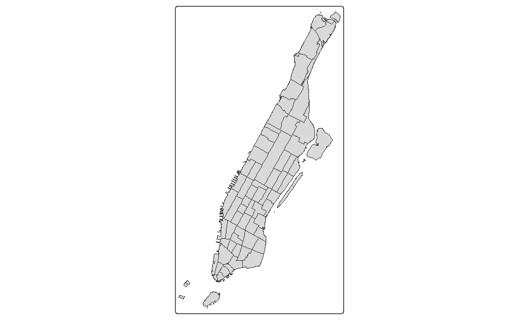

```r
# Selecting Manhattan
mht_shp = nyc_shp %>%
  filter(borough == "Manhattan")

tm_shape(mht_shp) +
  tm_polygons()
```

# Transforming the crs and plotting

```r
ny_air_sf <- ny_air %>%
  filter(!is.na(Site.Latitude) & !is.na(Site.Longitude)) %>%
  st_as_sf(coords = c("Site.Longitude", "Site.Latitude"), crs = 4326)

# Adjust the coordinate of shp
mht_shp = st_transform(mht_shp, st_crs(ny_air_sf))
st_crs(mht_shp)
```

```
Coordinate Reference System:
  User input: EPSG:4326
  wkt:
GEOGCRS["WGS 84",
    ENSEMBLE["World Geodetic System 1984 ensemble",
        MEMBER["World Geodetic System 1984 (Transit)"],
        MEMBER["World Geodetic System 1984 (G730)"],
        MEMBER["World Geodetic System 1984 (G873)"],
        MEMBER["World Geodetic System 1984 (G1150)"],
        MEMBER["World Geodetic System 1984 (G1674)"],
        MEMBER["World Geodetic System 1984 (G1762)"],
        MEMBER["World Geodetic System 1984 (G2139)"],
        MEMBER["World Geodetic System 1984 (G2296)"],
        ELLIPSOID["WGS 84",6378137,298.257223563,
            LENGTHUNIT["metre",1]],
        ENSEMBLEACCURACY[2.0]],
    PRIMEM["Greenwich",0,
        ANGLEUNIT["degree",0.0174532925199433]],
    CS[ellipsoidal,2],
        AXIS["geodetic latitude (Lat)",north,
            ORDER[1],
            ANGLEUNIT["degree",0.0174532925199433]],
        AXIS["geodetic longitude (Lon)",east,
            ORDER[2],
            ANGLEUNIT["degree",0.0174532925199433]],
    USAGE[
        SCOPE["Horizontal component of 3D system."],
        AREA["World."],
        BBOX[-90,-180,90,180]],
    ID["EPSG",4326]]
```

```
── tmap v3 code detected ────────────────────────────────────────────────────────────────────────────────────────────────────
[v3->v4] `tm_polygons()`: use 'fill' for the fill color of polygons/symbols (instead of 'col'), and 'col' for the outlines
(instead of 'border.col').[v3->v4] `tm_layout()`: use `tm_title()` instead of `tm_layout(title = )`
```

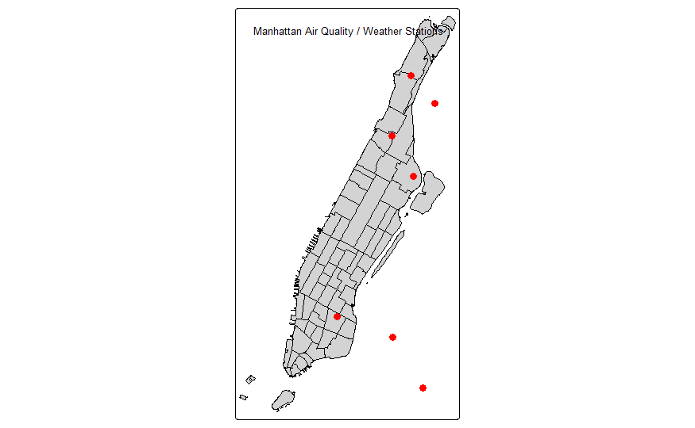

```r
# 使用 tmap 繪圖
tm_shape(mht_shp) +
  tm_polygons(col = "lightgray", border.col = "black") +  # 底圖 polygon
tm_shape(ny_air_sf) +
  tm_dots(size = 0.5, fill = "red") +                     # 測站點
  tm_layout(title = "Manhattan Air Quality / Weather Stations", frame = TRUE)
```